# Risk Factor Analysis

## Outcome Variable

**Outcome Variable:** sstunted

## Predictor Variables

**Intervention Variable:** predexfd6

**Adjustment Set:**

- arm
- sex
- W_mage
- meducyrs
- feducyrs
- hhwealth_quart
- hfoodsec
- W_mhtcm
- vagbrth
- W_gagebrth
- W_birthwt
- W_birthlen
- W_nrooms
- W_nchldlt5
- month
- brthmon
- W_parity
- impfloor
- impsan
- safeh20
- delta_W_mage
- delta_meducyrs
- delta_feducyrs
- delta_hhwealth_quart
- delta_hfoodsec
- delta_W_mhtcm
- delta_vagbrth
- delta_W_gagebrth
- delta_W_birthwt
- delta_W_birthlen
- delta_W_nrooms
- delta_W_nchldlt5
- delta_month
- delta_brthmon
- delta_W_parity
- delta_impfloor
- delta_impsan
- delta_safeh20

## Stratifying Variables

The analysis was stratified on these variable(s):

- agecat
- studyid
- country

## Data Summary

| agecat | studyid | country | predexfd6 | sstunted | n_cell | n |
| --- | --- | --- | --- | --- | --- | --- |
| Birth | ki0047075b-MAL-ED | BANGLADESH | 0 | 0 | 108 | 231 |
| Birth | ki0047075b-MAL-ED | BANGLADESH | 0 | 1 | 4 | 231 |
| Birth | ki0047075b-MAL-ED | BANGLADESH | 1 | 0 | 117 | 231 |
| Birth | ki0047075b-MAL-ED | BANGLADESH | 1 | 1 | 2 | 231 |
| Birth | ki0047075b-MAL-ED | BRAZIL | 0 | 0 | 142 | 175 |
| Birth | ki0047075b-MAL-ED | BRAZIL | 0 | 1 | 6 | 175 |
| Birth | ki0047075b-MAL-ED | BRAZIL | 1 | 0 | 26 | 175 |
| Birth | ki0047075b-MAL-ED | BRAZIL | 1 | 1 | 1 | 175 |
| Birth | ki0047075b-MAL-ED | INDIA | 0 | 0 | 170 | 190 |
| Birth | ki0047075b-MAL-ED | INDIA | 0 | 1 | 5 | 190 |
| Birth | ki0047075b-MAL-ED | INDIA | 1 | 0 | 13 | 190 |
| Birth | ki0047075b-MAL-ED | INDIA | 1 | 1 | 2 | 190 |
| Birth | ki0047075b-MAL-ED | NEPAL | 0 | 0 | 142 | 170 |
| Birth | ki0047075b-MAL-ED | NEPAL | 0 | 1 | 5 | 170 |
| Birth | ki0047075b-MAL-ED | NEPAL | 1 | 0 | 22 | 170 |
| Birth | ki0047075b-MAL-ED | NEPAL | 1 | 1 | 1 | 170 |
| Birth | ki0047075b-MAL-ED | PERU | 0 | 0 | 146 | 256 |
| Birth | ki0047075b-MAL-ED | PERU | 0 | 1 | 4 | 256 |
| Birth | ki0047075b-MAL-ED | PERU | 1 | 0 | 104 | 256 |
| Birth | ki0047075b-MAL-ED | PERU | 1 | 1 | 2 | 256 |
| Birth | ki0047075b-MAL-ED | SOUTH AFRICA | 0 | 0 | 207 | 211 |
| Birth | ki0047075b-MAL-ED | SOUTH AFRICA | 0 | 1 | 1 | 211 |
| Birth | ki0047075b-MAL-ED | SOUTH AFRICA | 1 | 0 | 3 | 211 |
| Birth | ki0047075b-MAL-ED | SOUTH AFRICA | 1 | 1 | 0 | 211 |
| Birth | ki0047075b-MAL-ED | TANZANIA, UNITED REPUBLIC OF | 0 | 0 | 113 | 119 |
| Birth | ki0047075b-MAL-ED | TANZANIA, UNITED REPUBLIC OF | 0 | 1 | 5 | 119 |
| Birth | ki0047075b-MAL-ED | TANZANIA, UNITED REPUBLIC OF | 1 | 0 | 1 | 119 |
| Birth | ki0047075b-MAL-ED | TANZANIA, UNITED REPUBLIC OF | 1 | 1 | 0 | 119 |
| Birth | ki1000108-CMC-V-BCS-2002 | INDIA | 0 | 0 | 0 | 7 |
| Birth | ki1000108-CMC-V-BCS-2002 | INDIA | 0 | 1 | 0 | 7 |

[output cut: 158 more lines]

The following strata were considered:

- agecat: 24 months, studyid: ki0047075b-MAL-ED, country: BANGLADESH
- agecat: 24 months, studyid: ki0047075b-MAL-ED, country: BRAZIL
- agecat: 24 months, studyid: ki0047075b-MAL-ED, country: INDIA
- agecat: 24 months, studyid: ki0047075b-MAL-ED, country: NEPAL
- agecat: 24 months, studyid: ki0047075b-MAL-ED, country: PERU
- agecat: 24 months, studyid: ki0047075b-MAL-ED, country: SOUTH AFRICA
- agecat: 24 months, studyid: ki0047075b-MAL-ED, country: TANZANIA, UNITED REPUBLIC OF
- agecat: 24 months, studyid: ki1000108-CMC-V-BCS-2002, country: INDIA
- agecat: 24 months, studyid: ki1000108-IRC, country: INDIA
- agecat: 24 months, studyid: ki1017093b-PROVIDE, country: BANGLADESH
- agecat: 24 months, studyid: ki1101329-Keneba, country: GAMBIA
- agecat: 24 months, studyid: ki1113344-GMS-Nepal, country: NEPAL
- agecat: 24 months, studyid: ki1148112-LCNI-5, country: MALAWI
- agecat: 24 months, studyid: kiGH5241-JiVitA-3, country: BANGLADESH
- agecat: 24 months, studyid: kiGH5241-JiVitA-4, country: BANGLADESH
- agecat: 6 months, studyid: ki0047075b-MAL-ED, country: BANGLADESH
- agecat: 6 months, studyid: ki0047075b-MAL-ED, country: BRAZIL
- agecat: 6 months, studyid: ki0047075b-MAL-ED, country: INDIA
- agecat: 6 months, studyid: ki0047075b-MAL-ED, country: NEPAL
- agecat: 6 months, studyid: ki0047075b-MAL-ED, country: PERU
- agecat: 6 months, studyid: ki0047075b-MAL-ED, country: SOUTH AFRICA
- agecat: 6 months, studyid: ki0047075b-MAL-ED, country: TANZANIA, UNITED REPUBLIC OF
- agecat: 6 months, studyid: ki1000108-CMC-V-BCS-2002, country: INDIA
- agecat: 6 months, studyid: ki1000108-IRC, country: INDIA
- agecat: 6 months, studyid: ki1000109-EE, country: PAKISTAN
- agecat: 6 months, studyid: ki1000304b-SAS-CompFeed, country: INDIA
- agecat: 6 months, studyid: ki1000304b-SAS-FoodSuppl, country: INDIA
- agecat: 6 months, studyid: ki1017093b-PROVIDE, country: BANGLADESH
- agecat: 6 months, studyid: ki1101329-Keneba, country: GAMBIA
- agecat: 6 months, studyid: ki1113344-GMS-Nepal, country: NEPAL
- agecat: 6 months, studyid: ki1148112-LCNI-5, country: MALAWI
- agecat: 6 months, studyid: kiGH5241-JiVitA-3, country: BANGLADESH
- agecat: 6 months, studyid: kiGH5241-JiVitA-4, country: BANGLADESH
- agecat: Birth, studyid: ki0047075b-MAL-ED, country: BANGLADESH
- agecat: Birth, studyid: ki0047075b-MAL-ED, country: BRAZIL
- agecat: Birth, studyid: ki0047075b-MAL-ED, country: INDIA
- agecat: Birth, studyid: ki0047075b-MAL-ED, country: NEPAL
- agecat: Birth, studyid: ki0047075b-MAL-ED, country: PERU
- agecat: Birth, studyid: ki0047075b-MAL-ED, country: SOUTH AFRICA
- agecat: Birth, studyid: ki0047075b-MAL-ED, country: TANZANIA, UNITED REPUBLIC OF
- agecat: Birth, studyid: ki1000108-CMC-V-BCS-2002, country: INDIA
- agecat: Birth, studyid: ki1000108-IRC, country: INDIA
- agecat: Birth, studyid: ki1000109-EE, country: PAKISTAN
- agecat: Birth, studyid: ki1000304b-SAS-CompFeed, country: INDIA
- agecat: Birth, studyid: ki1101329-Keneba, country: GAMBIA
- agecat: Birth, studyid: kiGH5241-JiVitA-3, country: BANGLADESH
- agecat: Birth, studyid: kiGH5241-JiVitA-4, country: BANGLADESH

### Dropped Strata

Some strata were dropped due to rare outcomes:

- agecat: Birth, studyid: ki0047075b-MAL-ED, country: BANGLADESH
- agecat: Birth, studyid: ki0047075b-MAL-ED, country: BRAZIL
- agecat: Birth, studyid: ki0047075b-MAL-ED, country: INDIA
- agecat: Birth, studyid: ki0047075b-MAL-ED, country: NEPAL
- agecat: Birth, studyid: ki0047075b-MAL-ED, country: PERU
- agecat: Birth, studyid: ki0047075b-MAL-ED, country: SOUTH AFRICA
- agecat: Birth, studyid: ki0047075b-MAL-ED, country: TANZANIA, UNITED REPUBLIC OF
- agecat: Birth, studyid: ki1000108-CMC-V-BCS-2002, country: INDIA
- agecat: Birth, studyid: ki1000108-IRC, country: INDIA
- agecat: Birth, studyid: ki1000109-EE, country: PAKISTAN
- agecat: Birth, studyid: ki1000304b-SAS-CompFeed, country: INDIA
- agecat: 6 months, studyid: ki0047075b-MAL-ED, country: BANGLADESH
- agecat: 6 months, studyid: ki0047075b-MAL-ED, country: BRAZIL
- agecat: 6 months, studyid: ki0047075b-MAL-ED, country: INDIA
- agecat: 6 months, studyid: ki0047075b-MAL-ED, country: NEPAL
- agecat: 6 months, studyid: ki0047075b-MAL-ED, country: PERU
- agecat: 6 months, studyid: ki0047075b-MAL-ED, country: SOUTH AFRICA
- agecat: 6 months, studyid: ki0047075b-MAL-ED, country: TANZANIA, UNITED REPUBLIC OF
- agecat: 6 months, studyid: ki1000108-CMC-V-BCS-2002, country: INDIA
- agecat: 6 months, studyid: ki1000108-IRC, country: INDIA
- agecat: 6 months, studyid: ki1000304b-SAS-CompFeed, country: INDIA
- agecat: 6 months, studyid: ki1000304b-SAS-FoodSuppl, country: INDIA
- agecat: 6 months, studyid: ki1017093b-PROVIDE, country: BANGLADESH
- agecat: 6 months, studyid: ki1148112-LCNI-5, country: MALAWI
- agecat: 24 months, studyid: ki0047075b-MAL-ED, country: BRAZIL
- agecat: 24 months, studyid: ki0047075b-MAL-ED, country: INDIA
- agecat: 24 months, studyid: ki0047075b-MAL-ED, country: NEPAL
- agecat: 24 months, studyid: ki0047075b-MAL-ED, country: PERU
- agecat: 24 months, studyid: ki0047075b-MAL-ED, country: SOUTH AFRICA
- agecat: 24 months, studyid: ki0047075b-MAL-ED, country: TANZANIA, UNITED REPUBLIC OF
- agecat: 24 months, studyid: ki1000108-CMC-V-BCS-2002, country: INDIA
- agecat: 24 months, studyid: ki1000108-IRC, country: INDIA
- agecat: 24 months, studyid: ki1148112-LCNI-5, country: MALAWI

## Methods Detail

We’re interested in the causal parameters $E[Y_a]$ for all values of $a \in \mathcal{A}$. These parameters represent the mean outcome if, possibly contrary to fact, we intervened to set all units to have $A=a$. Under the randomization and positivity assumptions, these are identified by the statistical parameters $\psi_a=E_W[E_{Y|A,W}(Y|A=a,W)]$. In addition, we’re interested in the mean of $Y$, $E[Y]$ under no intervention (the observed mean). We will estimate these parameters by using SuperLearner to fit the relevant likelihood factors – $E_{Y|A,W}(Y|A=a,W)$ and $p(A=a|W)$, and then updating our likelihood fit using a joint TMLE.

For unadjusted analyses ($W=\{\}$), initial likelihoods were estimated using Lrnr_glm to estimate the simple $E(Y|A)$ and Lrnr_mean to estimate $p(A)$. For adjusted analyses, a small library containing Lrnr_glmnet, Lrnr_xgboost, and Lrnr_mean was used.

Having estimated these parameters, we will then use the delta method to estimate relative risks and attributable risks relative to a prespecified baseline level of $A$.

# Results Detail

## Results Plots

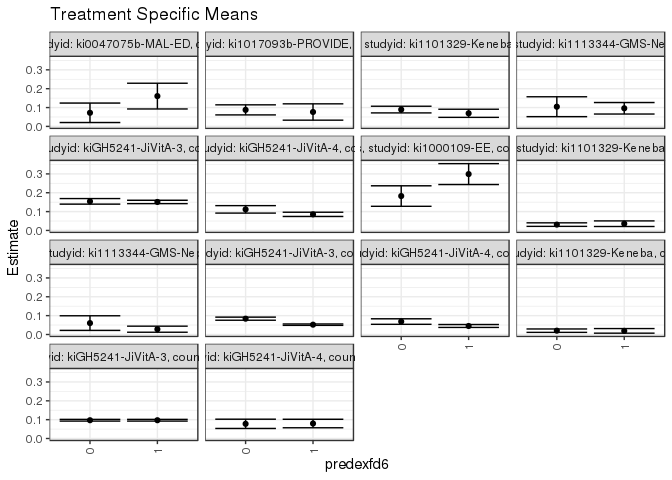

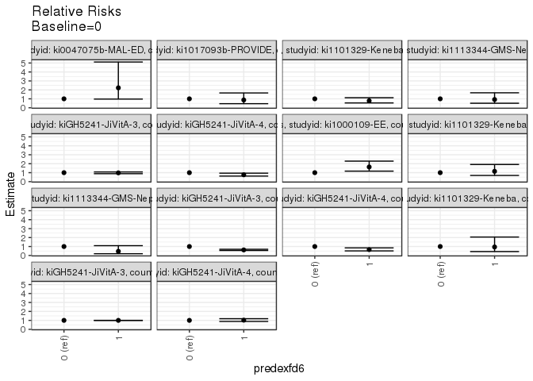

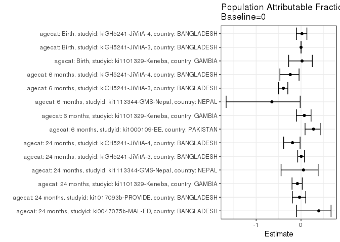

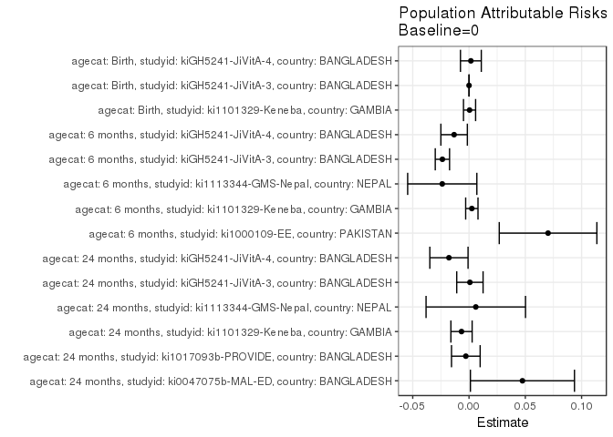

## Results Table

### Parameter: TSM

| agecat | studyid | country | intervention_level | baseline_level | estimate | ci_lower | ci_upper |
| --- | --- | --- | --- | --- | --- | --- | --- |
| Birth | ki1101329-Keneba | GAMBIA | 0 | NA | 0.0202301 | 0.0111305 | 0.0293296 |
| Birth | ki1101329-Keneba | GAMBIA | 1 | NA | 0.0191785 | 0.0070448 | 0.0313123 |
| Birth | kiGH5241-JiVitA-3 | BANGLADESH | 0 | NA | 0.0970357 | 0.0924646 | 0.1016069 |
| Birth | kiGH5241-JiVitA-3 | BANGLADESH | 1 | NA | 0.0970345 | 0.0924641 | 0.1016049 |
| Birth | kiGH5241-JiVitA-4 | BANGLADESH | 0 | NA | 0.0778827 | 0.0532759 | 0.1024894 |
| Birth | kiGH5241-JiVitA-4 | BANGLADESH | 1 | NA | 0.0795679 | 0.0570150 | 0.1021207 |
| 6 months | ki1000109-EE | PAKISTAN | 0 | NA | 0.1824797 | 0.1280964 | 0.2368630 |
| 6 months | ki1000109-EE | PAKISTAN | 1 | NA | 0.2989990 | 0.2435092 | 0.3544888 |
| 6 months | ki1101329-Keneba | GAMBIA | 0 | NA | 0.0310482 | 0.0216910 | 0.0404054 |
| 6 months | ki1101329-Keneba | GAMBIA | 1 | NA | 0.0356826 | 0.0208542 | 0.0505110 |
| 6 months | ki1113344-GMS-Nepal | NEPAL | 0 | NA | 0.0604078 | 0.0216077 | 0.0992079 |
| 6 months | ki1113344-GMS-Nepal | NEPAL | 1 | NA | 0.0279174 | 0.0118089 | 0.0440259 |
| 6 months | kiGH5241-JiVitA-3 | BANGLADESH | 0 | NA | 0.0838304 | 0.0756790 | 0.0919817 |
| 6 months | kiGH5241-JiVitA-3 | BANGLADESH | 1 | NA | 0.0520310 | 0.0483023 | 0.0557597 |
| 6 months | kiGH5241-JiVitA-4 | BANGLADESH | 0 | NA | 0.0686525 | 0.0541041 | 0.0832009 |
| 6 months | kiGH5241-JiVitA-4 | BANGLADESH | 1 | NA | 0.0450155 | 0.0372662 | 0.0527649 |
| 24 months | ki0047075b-MAL-ED | BANGLADESH | 0 | NA | 0.0721649 | 0.0205468 | 0.1237831 |
| 24 months | ki0047075b-MAL-ED | BANGLADESH | 1 | NA | 0.1607143 | 0.0925334 | 0.2288952 |
| 24 months | ki1017093b-PROVIDE | BANGLADESH | 0 | NA | 0.0877598 | 0.0610861 | 0.1144335 |
| 24 months | ki1017093b-PROVIDE | BANGLADESH | 1 | NA | 0.0763889 | 0.0329676 | 0.1198102 |
| 24 months | ki1101329-Keneba | GAMBIA | 0 | NA | 0.0892878 | 0.0716259 | 0.1069496 |
| 24 months | ki1101329-Keneba | GAMBIA | 1 | NA | 0.0694680 | 0.0479299 | 0.0910060 |
| 24 months | ki1113344-GMS-Nepal | NEPAL | 0 | NA | 0.1044109 | 0.0515712 | 0.1572505 |
| 24 months | ki1113344-GMS-Nepal | NEPAL | 1 | NA | 0.0961260 | 0.0656271 | 0.1266249 |
| 24 months | kiGH5241-JiVitA-3 | BANGLADESH | 0 | NA | 0.1543362 | 0.1395624 | 0.1691099 |
| 24 months | kiGH5241-JiVitA-3 | BANGLADESH | 1 | NA | 0.1511355 | 0.1421781 | 0.1600929 |
| 24 months | kiGH5241-JiVitA-4 | BANGLADESH | 0 | NA | 0.1117515 | 0.0919591 | 0.1315439 |
| 24 months | kiGH5241-JiVitA-4 | BANGLADESH | 1 | NA | 0.0853094 | 0.0740990 | 0.0965198 |

### Parameter: E(Y)

| agecat | studyid | country | intervention_level | baseline_level | estimate | ci_lower | ci_upper |
| --- | --- | --- | --- | --- | --- | --- | --- |
| Birth | ki1101329-Keneba | GAMBIA | NA | NA | 0.0206995 | 0.0132415 | 0.0281575 |
| Birth | kiGH5241-JiVitA-3 | BANGLADESH | NA | NA | 0.0970548 | 0.0924831 | 0.1016266 |
| Birth | kiGH5241-JiVitA-4 | BANGLADESH | NA | NA | 0.0795306 | 0.0569401 | 0.1021211 |
| 6 months | ki1000109-EE | PAKISTAN | NA | NA | 0.2526882 | 0.2084696 | 0.2969067 |
| 6 months | ki1101329-Keneba | GAMBIA | NA | NA | 0.0335430 | 0.0254620 | 0.0416240 |
| 6 months | ki1113344-GMS-Nepal | NEPAL | NA | NA | 0.0366300 | 0.0208588 | 0.0524012 |
| 6 months | kiGH5241-JiVitA-3 | BANGLADESH | NA | NA | 0.0601846 | 0.0563303 | 0.0640390 |
| 6 months | kiGH5241-JiVitA-4 | BANGLADESH | NA | NA | 0.0554121 | 0.0477101 | 0.0631140 |
| 24 months | ki0047075b-MAL-ED | BANGLADESH | NA | NA | 0.1196172 | 0.0755162 | 0.1637183 |
| 24 months | ki1017093b-PROVIDE | BANGLADESH | NA | NA | 0.0849220 | 0.0621566 | 0.1076874 |
| 24 months | ki1101329-Keneba | GAMBIA | NA | NA | 0.0826173 | 0.0687407 | 0.0964939 |
| 24 months | ki1113344-GMS-Nepal | NEPAL | NA | NA | 0.1104167 | 0.0823500 | 0.1384833 |
| 24 months | kiGH5241-JiVitA-3 | BANGLADESH | NA | NA | 0.1551159 | 0.1463315 | 0.1639003 |
| 24 months | kiGH5241-JiVitA-4 | BANGLADESH | NA | NA | 0.0939147 | 0.0835386 | 0.1042909 |

### Parameter: RR

| agecat | studyid | country | intervention_level | baseline_level | estimate | ci_lower | ci_upper |
| --- | --- | --- | --- | --- | --- | --- | --- |
| Birth | ki1101329-Keneba | GAMBIA | 0 | 0 | 1.0000000 | 1.0000000 | 1.0000000 |
| Birth | ki1101329-Keneba | GAMBIA | 1 | 0 | 0.9480189 | 0.4361918 | 2.0604233 |
| Birth | kiGH5241-JiVitA-3 | BANGLADESH | 0 | 0 | 1.0000000 | 1.0000000 | 1.0000000 |
| Birth | kiGH5241-JiVitA-3 | BANGLADESH | 1 | 0 | 0.9999869 | 0.9998636 | 1.0001101 |
| Birth | kiGH5241-JiVitA-4 | BANGLADESH | 0 | 0 | 1.0000000 | 1.0000000 | 1.0000000 |
| Birth | kiGH5241-JiVitA-4 | BANGLADESH | 1 | 0 | 1.0216376 | 0.8809319 | 1.1848174 |
| 6 months | ki1000109-EE | PAKISTAN | 0 | 0 | 1.0000000 | 1.0000000 | 1.0000000 |
| 6 months | ki1000109-EE | PAKISTAN | 1 | 0 | 1.6385329 | 1.1728672 | 2.2890827 |
| 6 months | ki1101329-Keneba | GAMBIA | 0 | 0 | 1.0000000 | 1.0000000 | 1.0000000 |
| 6 months | ki1101329-Keneba | GAMBIA | 1 | 0 | 1.1492622 | 0.6892891 | 1.9161825 |
| 6 months | ki1113344-GMS-Nepal | NEPAL | 0 | 0 | 1.0000000 | 1.0000000 | 1.0000000 |
| 6 months | ki1113344-GMS-Nepal | NEPAL | 1 | 0 | 0.4621488 | 0.1952653 | 1.0938019 |
| 6 months | kiGH5241-JiVitA-3 | BANGLADESH | 0 | 0 | 1.0000000 | 1.0000000 | 1.0000000 |
| 6 months | kiGH5241-JiVitA-3 | BANGLADESH | 1 | 0 | 0.6206700 | 0.5560424 | 0.6928092 |
| 6 months | kiGH5241-JiVitA-4 | BANGLADESH | 0 | 0 | 1.0000000 | 1.0000000 | 1.0000000 |
| 6 months | kiGH5241-JiVitA-4 | BANGLADESH | 1 | 0 | 0.6557013 | 0.5082944 | 0.8458567 |
| 24 months | ki0047075b-MAL-ED | BANGLADESH | 0 | 0 | 1.0000000 | 1.0000000 | 1.0000000 |
| 24 months | ki0047075b-MAL-ED | BANGLADESH | 1 | 0 | 2.2270408 | 0.9695218 | 5.1156260 |
| 24 months | ki1017093b-PROVIDE | BANGLADESH | 0 | 0 | 1.0000000 | 1.0000000 | 1.0000000 |
| 24 months | ki1017093b-PROVIDE | BANGLADESH | 1 | 0 | 0.8704313 | 0.4568736 | 1.6583376 |
| 24 months | ki1101329-Keneba | GAMBIA | 0 | 0 | 1.0000000 | 1.0000000 | 1.0000000 |
| 24 months | ki1101329-Keneba | GAMBIA | 1 | 0 | 0.7780235 | 0.5396697 | 1.1216501 |
| 24 months | ki1113344-GMS-Nepal | NEPAL | 0 | 0 | 1.0000000 | 1.0000000 | 1.0000000 |
| 24 months | ki1113344-GMS-Nepal | NEPAL | 1 | 0 | 0.9206512 | 0.5064831 | 1.6734985 |
| 24 months | kiGH5241-JiVitA-3 | BANGLADESH | 0 | 0 | 1.0000000 | 1.0000000 | 1.0000000 |
| 24 months | kiGH5241-JiVitA-3 | BANGLADESH | 1 | 0 | 0.9792616 | 0.8865915 | 1.0816180 |
| 24 months | kiGH5241-JiVitA-4 | BANGLADESH | 0 | 0 | 1.0000000 | 1.0000000 | 1.0000000 |
| 24 months | kiGH5241-JiVitA-4 | BANGLADESH | 1 | 0 | 0.7633849 | 0.6172899 | 0.9440563 |

### Parameter: PAR

| agecat | studyid | country | intervention_level | baseline_level | estimate | ci_lower | ci_upper |
| --- | --- | --- | --- | --- | --- | --- | --- |
| Birth | ki1101329-Keneba | GAMBIA | 0 | NA | 0.0004694 | -0.0049131 | 0.0058519 |
| Birth | kiGH5241-JiVitA-3 | BANGLADESH | 0 | NA | 0.0000191 | 0.0000107 | 0.0000274 |
| Birth | kiGH5241-JiVitA-4 | BANGLADESH | 0 | NA | 0.0016480 | -0.0076047 | 0.0109006 |
| 6 months | ki1000109-EE | PAKISTAN | 0 | NA | 0.0702085 | 0.0268495 | 0.1135674 |
| 6 months | ki1101329-Keneba | GAMBIA | 0 | NA | 0.0024947 | -0.0029792 | 0.0079687 |
| 6 months | ki1113344-GMS-Nepal | NEPAL | 0 | NA | -0.0237778 | -0.0545033 | 0.0069478 |
| 6 months | kiGH5241-JiVitA-3 | BANGLADESH | 0 | NA | -0.0236457 | -0.0299950 | -0.0172965 |
| 6 months | kiGH5241-JiVitA-4 | BANGLADESH | 0 | NA | -0.0132404 | -0.0249948 | -0.0014860 |
| 24 months | ki0047075b-MAL-ED | BANGLADESH | 0 | NA | 0.0474523 | 0.0012340 | 0.0936706 |
| 24 months | ki1017093b-PROVIDE | BANGLADESH | 0 | NA | -0.0028378 | -0.0155620 | 0.0098864 |
| 24 months | ki1101329-Keneba | GAMBIA | 0 | NA | -0.0066704 | -0.0161023 | 0.0027614 |
| 24 months | ki1113344-GMS-Nepal | NEPAL | 0 | NA | 0.0060058 | -0.0381621 | 0.0501737 |
| 24 months | kiGH5241-JiVitA-3 | BANGLADESH | 0 | NA | 0.0007797 | -0.0109203 | 0.0124798 |
| 24 months | kiGH5241-JiVitA-4 | BANGLADESH | 0 | NA | -0.0178368 | -0.0348095 | -0.0008640 |

### Parameter: PAF

| agecat | studyid | country | intervention_level | baseline_level | estimate | ci_lower | ci_upper |
| --- | --- | --- | --- | --- | --- | --- | --- |
| Birth | ki1101329-Keneba | GAMBIA | 0 | NA | 0.0226775 | -0.2751577 | 0.2509482 |
| Birth | kiGH5241-JiVitA-3 | BANGLADESH | 0 | NA | 0.0001966 | 0.0001106 | 0.0002825 |
| Birth | kiGH5241-JiVitA-4 | BANGLADESH | 0 | NA | 0.0207213 | -0.1031307 | 0.1306680 |
| 6 months | ki1000109-EE | PAKISTAN | 0 | NA | 0.2778463 | 0.0895850 | 0.4271778 |
| 6 months | ki1101329-Keneba | GAMBIA | 0 | NA | 0.0743744 | -0.1033968 | 0.2235045 |
| 6 months | ki1113344-GMS-Nepal | NEPAL | 0 | NA | -0.6491334 | -1.6690460 | -0.0189562 |
| 6 months | kiGH5241-JiVitA-3 | BANGLADESH | 0 | NA | -0.3928866 | -0.4994268 | -0.2939164 |
| 6 months | kiGH5241-JiVitA-4 | BANGLADESH | 0 | NA | -0.2389442 | -0.4703144 | -0.0439826 |
| 24 months | ki0047075b-MAL-ED | BANGLADESH | 0 | NA | 0.3967010 | -0.1002381 | 0.6691901 |
| 24 months | ki1017093b-PROVIDE | BANGLADESH | 0 | NA | -0.0334166 | -0.1944070 | 0.1058744 |
| 24 months | ki1101329-Keneba | GAMBIA | 0 | NA | -0.0807390 | -0.2002905 | 0.0269049 |
| 24 months | ki1113344-GMS-Nepal | NEPAL | 0 | NA | 0.0543921 | -0.4443521 | 0.3809166 |
| 24 months | kiGH5241-JiVitA-3 | BANGLADESH | 0 | NA | 0.0050266 | -0.0733407 | 0.0776722 |
| 24 months | kiGH5241-JiVitA-4 | BANGLADESH | 0 | NA | -0.1899251 | -0.3867863 | -0.0210093 |